# Lab 4

Danielle Caccamo

Due on 4/12/25 at 11:59 pm

For this lab assignment you will have to create a data set called . This data set should contain statcast data for all balls in play from 2017-2021. Statcast data can be obtained from this link:

https://uofi.app.box.com/file/1449126291821?s=we34tcz4wqdu063zpzuwjvb4r6u9j21s

There is a script called in the **stat430sp25** repo to aid you in this task of creating the data set.

**Question 1** Do the following for a year of your choice with the exception of 2020:

1. List the batters with the ten highest average exit velocities on batted balls.

```r
sc_bip_small <- read_csv("C:/Users/danie/Desktop/stat430/sp25_stat430_caccamo3/labs/lab4/sc_bip_small.csv")
batters_velocities <- sc_bip_small %>%
  mutate(year = year(game_date)) %>%
  filter(year == 2019) %>%
  group_by(batter_name, year) %>%
  summarise(N = n(),
            avg_ls = mean(launch_speed, na.rm = TRUE),
            var_ls = var(launch_speed, na.rm = TRUE),
            .groups = "drop") %>%
  filter(N > 20) %>%
  select(batter_name, N, avg_ls, year) %>%
  arrange(desc(avg_ls))
head(batters_velocities, n=10)
```

| batter_name | N | avg_ls | year |
| --- | --- | --- | --- |
| Kyle Holder | 23 | 97.80000 | 2019 |
| Lucas Erceg | 32 | 97.15000 | 2019 |
| Michael Lorenzen | 33 | 96.47500 | 2019 |
| Nick Tanielu | 37 | 96.40000 | 2019 |
| Aaron Judge | 282 | 95.97695 | 2019 |
| Pedro Florimón Jr. | 21 | 95.03333 | 2019 |
| Blake Trahan | 27 | 94.80000 | 2019 |
| Preston Tucker | 21 | 94.50000 | 2019 |
| Troy Tulowitzki | 22 | 94.37500 | 2019 |
| Miguel Sanó | 226 | 94.36239 | 2019 |

2. Plot the distribution of exit velocities across batters. Does exit velocity vary significantly across batters? Explain your reasoning.

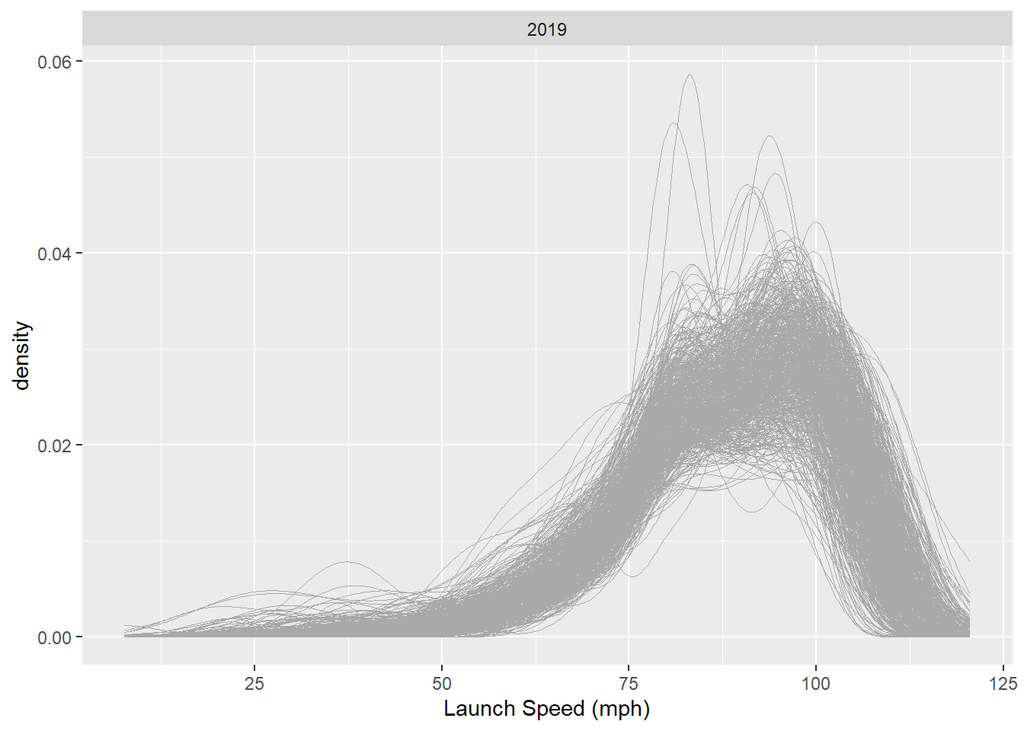

```r
sc_bip_small = sc_bip_small %>% mutate(year = year(game_date))

EV_dist_batters <- sc_bip_small %>%
  filter(!is.na(launch_speed)) %>%
  inner_join(batters_velocities, by = c("batter_name", "year"))

EV_dist_batters = batters_velocities %>%
    inner_join(sc_bip_small %>% filter(!is.na(launch_speed)),
                         by = c("batter_name","year"))

EV_dist_batters <- EV_dist_batters %>%
  group_by(batter_name, year) %>%
  filter(n() >= 30)%>%
  filter(year == 2019)


ls_plot <- ggplot(EV_dist_batters,
  aes(x = launch_speed, group = batter_name)) +
  geom_density(linewidth = 0.1, color = "darkgray") +
  scale_x_continuous("Launch Speed (mph)") +
  facet_wrap(~year)
ls_plot
```

```r
#The distribution of exit velocities across batters follows a general trend with the peak density around 90-100 mph with a few outliers around 80 mph. There are multiple overlapping density curves suggesting that while there is some variation in exit velocities among batters, many follow a similar distribution.
```

3. List the pitchers with the ten highest average exit velocities allowed on batted balls.

```r
pitchers_velocities <- sc_bip_small %>%
  mutate(year = year(game_date))%>%
  filter(year == 2019)%>%
  group_by(pitcher_name, year) %>%
  summarise(N = n(),
            avg_ls = mean(launch_speed, na.rm = TRUE),
            var_ls = var(launch_speed, na.rm = TRUE),
            .groups = "drop") %>%
  filter(N > 20) %>%
  select(pitcher_name, N, avg_ls, year) %>%
  arrange(desc(avg_ls))
head(pitchers_velocities, n=10)
```

| pitcher_name | N | avg_ls | year |
| --- | --- | --- | --- |
| Pedro Araújo | 27 | 100.73333 | 2019 |
| Parker Curry | 23 | 96.55000 | 2019 |
| Reymin Guduan | 35 | 96.32000 | 2019 |
| Luis Ortiz | 23 | 95.87000 | 2019 |
| Andrew Moore | 24 | 95.35882 | 2019 |
| Josh Sborz | 37 | 95.32500 | 2019 |
| Nick Green | 28 | 95.16250 | 2019 |
| Jonny Venters | 53 | 95.13438 | 2019 |
| Alex Cobb | 80 | 94.91400 | 2019 |
| Cody Allen | 95 | 94.50000 | 2019 |

4. Plot the distribution of exit velocities allowed across pitchers. Does exit velocity allowed vary significantly across batters? Explain your reasoning.

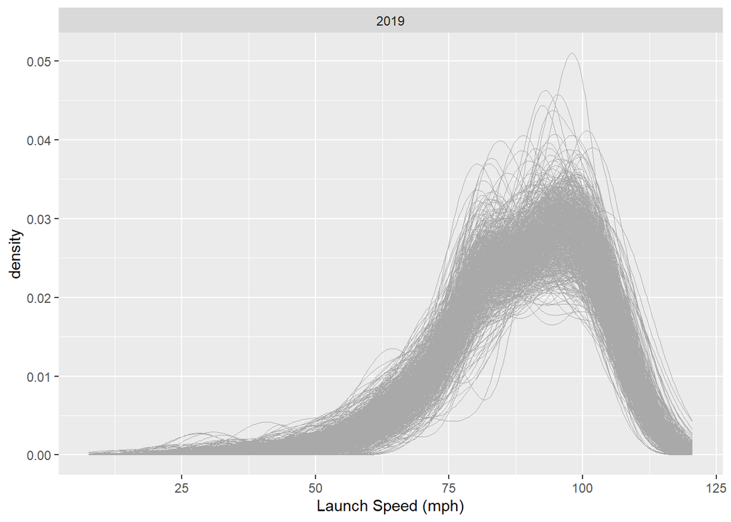

```r
EV_dist_pitchers <- sc_bip_small %>%
  filter(!is.na(launch_speed)) %>%
  inner_join(pitchers_velocities, by = c("pitcher_name", "year"))

EV_dist_pitchers = pitchers_velocities %>%
    inner_join(sc_bip_small %>% filter(!is.na(launch_speed)),
                         by = c("pitcher_name","year"))

EV_dist_pitchers <- EV_dist_pitchers %>%
  group_by(pitcher_name, year) %>%
  filter(n() >= 20)%>%
  filter(year == 2019)


ls_plot_pitchers <- ggplot(EV_dist_pitchers,
  aes(x = launch_speed, group = pitcher_name)) +
  geom_density(linewidth = 0.1, color = "darkgray") +
  scale_x_continuous("Launch Speed (mph)") +
  facet_wrap(~year)
ls_plot_pitchers
```

```r
#The distribution of exit velocities across pitchers sees a majority of exit velocities between 75 and 110 mph with a peak around 90-100 mph. Again, there are multiple overlapping curves suggesting many follow a similar distribution with slight variations. With the slight variation, this suggests that exit velocity does vary among pitchers but not to an extreme degree.
```

5. Compute the correlation for exit velocity for batters between the first and second half of the season you chose.

```r
season_length = difftime(max(EV_dist_batters$game_date), min(EV_dist_batters$game_date), units = "days")
half_length = season_length/2
half_length
```

```
## Time difference of 121.5 days
```

```r
half_length_split = min(EV_dist_batters$game_date) + half_length
half_length_split
```

```
## [1] "2019-07-01"
```

```r
EV_dist_batters_first = EV_dist_batters%>%
  filter(game_date < half_length_split)

EV_dist_batters_last = EV_dist_batters%>%
  filter(game_date > half_length_split)

sc_split_wide_first <- EV_dist_batters_first %>%
  group_by(batter_name, year) %>%
  summarise(avg_ls = mean(launch_speed), .groups = "drop") %>%
  spread(key = year, value = avg_ls)%>%
  rename("2019_first" = "2019")


sc_split_wide_last <- EV_dist_batters_last %>%
  group_by(batter_name, year) %>%
  summarise(avg_ls = mean(launch_speed), .groups = "drop") %>%
  spread(key = year, value = avg_ls)%>%
  rename("2019_last" = "2019")


sc_split = inner_join(sc_split_wide_first, sc_split_wide_last, by = "batter_name")

correlation_value <- cor(sc_split %>% select(`2019_first`,`2019_last`)%>% filter(complete.cases(.)))[1,2]
correlation_value
```

```
## [1] 0.508189
```

```r
#A correlation value of 0.508 indicated a moderate positive relationship between a batter's exit velocity in the first and second half of the season. A correlation value above 0.5 suggests that batters with higher exit velocities in the first half of the season tend to maintain relatively high exit velocities in the second half. Since the correlation value is not extremely strong, there is some variability, meaning that some batters may experience fluctuations in their exit velocities between halves.
```

6. On the basis of your calculations, do you believe exit velocity as a batter skill? Explain.

Based on my calculations, I would argue that exit velocity is not particular a skill. In part B, the distribution of exit velocities across batters shows a general trend with a few outliers near 80 mph, suggesting batters share a similar range of exit velocities with only minor variation. Additionally, the correlation value of 0.508 calculated in part E suggesting that batters tend to maintain their exit velocities. I see a skill as something that can be people can master/specialize in, and in these calculations I feel that exit velocity is more like a consistent trait rather than a skill.

**Question 2** In this question we will try to predict next years [slugging percentage](https://en.wikipedia.org/wiki/Slugging_percentage) using several variables including statcast variables. Load in the data set and run the code below to calculate some possibly important variables that encode launch angle and exit velocity distributional information for each player.

```r
foo = sc_bip_small %>%
  mutate(yearID = year(game_date)) %>%
  group_by(batter_name, yearID) %>%
  summarise(N = n(), launch_angle = launch_angle, launch_speed = launch_speed) %>%
  filter(N >= 10) %>%
  summarise(avg_la = mean(launch_angle, na.rm = TRUE),
            sd_la = sd(launch_angle, na.rm = TRUE),
            la10 = quantile(launch_angle, prob = c(0.10), na.rm = TRUE),
            la25 = quantile(launch_angle, prob = c(0.25), na.rm = TRUE),
            la50 = quantile(launch_angle, prob = c(0.50), na.rm = TRUE),
            la75 = quantile(launch_angle, prob = c(0.75), na.rm = TRUE),
            la90 = quantile(launch_angle, prob = c(0.90), na.rm = TRUE),
            avg_ev = mean(launch_speed, na.rm = TRUE),
            sd_ev = sd(launch_speed, na.rm = TRUE),
            ev10 = quantile(launch_speed, prob = c(0.10), na.rm = TRUE),
            ev25 = quantile(launch_speed, prob = c(0.25), na.rm = TRUE),
            ev50 = quantile(launch_speed, prob = c(0.50), na.rm = TRUE),
            ev75 = quantile(launch_speed, prob = c(0.75), na.rm = TRUE),
            ev90 = quantile(launch_speed, prob = c(0.90), na.rm = TRUE),
            ) %>%
  rename(name = batter_name)
```

- Create a data frame for batters that contains slugging percentage (SLG) for each player. Call this data frame . This data frame should contain the following variables: , , , , and . You can restrict attention to batters who had at least 200 ABs and who only played on a single team ( in the data frame in the package).

```r
bat_stat <- Batting%>%
  group_by(playerID, yearID)%>%
  filter(AB>=200, stint == 1)%>%
  mutate(SLG = (H + X2B + 2*X3B + 3*HR)/AB)%>%
  left_join(People, by = "playerID") %>%
  group_by(playerID, yearID)%>%
  mutate(name = paste(nameFirst, nameLast, sep = " "))%>%
  select(name, yearID, teamID, AB, SLG)
```

- Merge into using or a similar function. Run the following code which creates new variables and which are a player’s slugging percentage and team for the next season. The code also creates a categorical variable which indicates whether the player’s next season is with the Rockies. Note that you may have to change the argument in the call below to get it to work.

```r
bat_stat = bat_stat%>%
  inner_join(foo, by = c("name", "yearID"))
```

```r
bar = bat_stat %>% mutate(yearID = ifelse(yearID == 2021, 2020, yearID)) %>%
  group_by(name, yearID) %>%
  summarise(SLG, teamID) %>%
  mutate(SLG_next = SLG[match(yearID, yearID-1)]) %>%
  mutate(team_next = teamID[match(yearID, yearID-1)]) %>%
  mutate(yearID = ifelse(yearID == 2020, 2021, yearID)) %>%
  select(-SLG,-teamID)


bat_stat = inner_join(bat_stat, bar, by = c("name", "yearID")) %>%
  mutate(COL = ifelse(team_next == "COL",1,0)) %>%
  ungroup() %>%
  filter(complete.cases(.))
```

- We are going to use a simple procedure to assess predictive performance. Run the code below to split into a model training data set and a model testing data set .

```r
set.seed(13)
ind = sample(1:nrow(bat_stat), size = 400, replace = FALSE)
train = bat_stat[ind, ]
test = bat_stat[-ind, ]
```

- Fit and compare the following models. Which model would you select for predicting slugging percentage (root mean squared prediction error is a good metric for assessing predictive performance)? Are statcast variables important for predicting slugging percentage? Explain. Try to find a model which offers better predictive performance than the best model below. Comment on the success of your efforts.

```r
m_big = lm(SLG_next ~ SLG + avg_la + avg_ev + team_next + sd_la + sd_ev +
           sd_la*avg_la + sd_ev*avg_ev +
           la10 + la25 + la50 + la75 + la90 +
           ev10 + ev25 + ev50 + ev75 + ev90,
         data = train)
summary(m_big)
```

```
##
## Call:
## lm(formula = SLG_next ~ SLG + avg_la + avg_ev + team_next + sd_la +
##     sd_ev + sd_la * avg_la + sd_ev * avg_ev + la10 + la25 + la50 +
##     la75 + la90 + ev10 + ev25 + ev50 + ev75 + ev90, data = train)
##
## Residuals:
##       Min        1Q    Median        3Q       Max
## -0.168235 -0.038370 -0.004372  0.039737  0.192251
##
## Coefficients:
##                Estimate Std. Error t value Pr(>|t|)
## (Intercept)   0.0682383  1.7572677   0.039   0.9690
## SLG           0.1367197  0.0690038   1.981   0.0483 *
## avg_la       -0.0005199  0.0116904  -0.044   0.9646
## avg_ev       -0.0043776  0.0281968  -0.155   0.8767
## team_nextATL  0.0321464  0.0263098   1.222   0.2226
## team_nextBAL -0.0255602  0.0238653  -1.071   0.2849
## team_nextBOS  0.0041199  0.0272186   0.151   0.8798
## team_nextCHA -0.0168275  0.0285073  -0.590   0.5554
## team_nextCHN  0.0030321  0.0256089   0.118   0.9058
## team_nextCIN  0.0369820  0.0264524   1.398   0.1630
## team_nextCLE -0.0200982  0.0249857  -0.804   0.4217
## team_nextCOL  0.0415997  0.0248759   1.672   0.0954 .
## team_nextDET -0.0220053  0.0246388  -0.893   0.3724
## team_nextHOU  0.0219490  0.0241471   0.909   0.3640
## team_nextKCA  0.0103831  0.0268562   0.387   0.6993
## team_nextLAA  0.0016290  0.0237425   0.069   0.9453
## team_nextLAN  0.0369995  0.0233019   1.588   0.1132
## team_nextMIA -0.0193020  0.0267888  -0.721   0.4717
## team_nextMIL -0.0139649  0.0231980  -0.602   0.5476
## team_nextMIN  0.0353783  0.0235876   1.500   0.1345
## team_nextNYA -0.0042844  0.0220824  -0.194   0.8463
## team_nextNYN -0.0070883  0.0254380  -0.279   0.7807
## team_nextOAK -0.0121175  0.0231361  -0.524   0.6008
## team_nextPHI  0.0072317  0.0236066   0.306   0.7595
## team_nextPIT  0.0320817  0.0256342   1.252   0.2116
## team_nextSDN -0.0378212  0.0238495  -1.586   0.1137
## team_nextSEA -0.0089667  0.0238106  -0.377   0.7067
## team_nextSFN -0.0129810  0.0229650  -0.565   0.5723
```

[output cut: 10 more lines]

```
## la75          0.0061950  0.0030686   2.019   0.0443 *
## la90          0.0003682  0.0019573   0.188   0.8509
## ev10         -0.0001859  0.0033490  -0.055   0.9558
## ev25         -0.0044231  0.0046223  -0.957   0.3393
## ev50          0.0034469  0.0071046   0.485   0.6279
## ev75         -0.0058796  0.0077236  -0.761   0.4470
## ev90          0.0124172  0.0069571   1.785   0.0751 .
## avg_la:sd_la -0.0002138  0.0003824  -0.559   0.5763
## avg_ev:sd_ev  0.0007822  0.0014203   0.551   0.5822
## ---
## Signif. codes:  0 '***' 0.001 '**' 0.01 '*' 0.05 '.' 0.1 ' ' 1
##
## Residual standard error: 0.06479 on 353 degrees of freedom
## Multiple R-squared:  0.3608, Adjusted R-squared:  0.2775
## F-statistic: 4.332 on 46 and 353 DF,  p-value: 1.081e-15
```

```r
m_small = lm(SLG_next ~ SLG + avg_la + avg_ev + COL,
         data = train)
summary(m_small)
```

```
##
## Call:
## lm(formula = SLG_next ~ SLG + avg_la + avg_ev + COL, data = train)
##
## Residuals:
##       Min        1Q    Median        3Q       Max
## -0.185536 -0.042172 -0.005755  0.036966  0.200678
##
## Coefficients:
##               Estimate Std. Error t value Pr(>|t|)
## (Intercept) -0.7546014  0.1460446  -5.167 3.78e-07 ***
## SLG          0.2056147  0.0611032   3.365  0.00084 ***
## avg_la       0.0012067  0.0007799   1.547  0.12261
## avg_ev       0.0122408  0.0017961   6.815 3.53e-11 ***
## COL          0.0356869  0.0195599   1.824  0.06883 .
## ---
## Signif. codes:  0 '***' 0.001 '**' 0.01 '*' 0.05 '.' 0.1 ' ' 1
##
## Residual standard error: 0.06571 on 395 degrees of freedom
## Multiple R-squared:  0.2642, Adjusted R-squared:  0.2568
## F-statistic: 35.46 on 4 and 395 DF,  p-value: < 2.2e-16
```

```r
m_smaller = lm(SLG_next ~ SLG  + COL, data = train)
summary(m_smaller)
```

```
##
## Call:
## lm(formula = SLG_next ~ SLG + COL, data = train)
##
## Residuals:
##       Min        1Q    Median        3Q       Max
## -0.161816 -0.046513 -0.008289  0.041908  0.211248
##
## Coefficients:
##             Estimate Std. Error t value Pr(>|t|)
## (Intercept)  0.23161    0.02310  10.026   <2e-16 ***
## SLG          0.45269    0.05070   8.928   <2e-16 ***
## COL          0.03088    0.02040   1.514    0.131
## ---
## Signif. codes:  0 '***' 0.001 '**' 0.01 '*' 0.05 '.' 0.1 ' ' 1
##
## Residual standard error: 0.06938 on 397 degrees of freedom
## Multiple R-squared:  0.1757, Adjusted R-squared:  0.1716
## F-statistic: 42.32 on 2 and 397 DF,  p-value: < 2.2e-16
```